# Análise de Riscos Competitivos com Modelo de Fine e Gray

Isabel

2025-05-28

Abrindo dados

## Classificações

Durante esta análise, os medicamentos utilizados foram reagrupados em duas categorias principais para facilitar a comparação de seus efeitos sobre os desfechos de tratamento:

- Isoniazida: Inclui os esquemas baseados exclusivamente neste fármaco, como “Isoniazida”, “Isoniazida - 6H” e “Isoniazida - 9H”;
- Outros: Inclui os esquemas baseados em “Rifampicina” e em combinações como “Rifapentina + Isoniazida - 3HP”.

Além disso, os diferentes motivos de encerramento do tratamento foram organizados em oito categorias numeradas de 1 a 8, correspondentes aos seguintes eventos:

1. Óbito
2. Interrupção do tratamento
3. Suspenso por condição clínica desfavorável ao tratamento
4. Suspenso por PT < 5mm em quimioprofilaxia primária
5. Suspenso por reação adversa
6. Transferido para outro país
7. Tratamento completo
8. Tuberculose ativa

Cada um desses desfechos foi modelado individualmente como evento de interesse em análises de riscos competitivos, utilizando o modelo de Fine e Gray.

## Justificativa para não ajuste do modelo Fine & Gray em alguns desfechos

Durante a análise dos diferentes motivos de encerramento do tratamento, o modelo de riscos competitivos de Fine & Gray **não pôde ser ajustado** para os seguintes desfechos:  
- Óbito (caso 1) - Suspenso por condição clínica desfavorável ao tratamento (caso 3) - Suspenso por PT < 5mm em quimioprofilaxia primária (caso 4) - Suspenso por reação adversa (caso 5) - Transferido para outro país (caso 6) - Tuberculose ativa (caso 8)

Os motivos principais para a não execução do modelo nestes casos são:

- **Número Insuficiente de Eventos:**  
  O modelo Fine & Gray requer um número mínimo de casos do evento de interesse para conseguir estimar o efeito das variáveis. Se há poucos ou nenhum registro desse desfecho, o modelo não consegue ser ajustado.  
  *Exemplo leigo: Imagine tentar descobrir o que faz alguém ser aprovado em uma prova, mas na sua turma ninguém foi aprovado. Não tem como analisar o que leva à aprovação se nunca aconteceu!*
- **Separação Completa ou Dados Constantes:**  
  Se todas as pessoas de determinado grupo **nunca** ou **sempre** têm o evento, ou se há uma combinação das covariáveis que resulta em sempre ter ou nunca ter o desfecho, o modelo fica matematicamente travado. *Exemplo leigo: É como tentar entender por que algumas pessoas ficam gripadas e outras não,* *mas todos do seu estudo ficaram gripados. Não dá para comparar quem ficou e quem não ficou, porque só tem um tipo de caso.*
- **Dados Faltantes ou Ausência de Evento:**  
  Se o desfecho não está presente nos dados (exemplo: ninguém foi transferido para outro país), o modelo não é executado. *Exemplo leigo: É como tentar analisar quem da sua sala já viajou para a Lua, mas ninguém nunca viajou.*

**Resumo:**  
O modelo Fine & Gray não rodou nesses casos porque **faltaram casos suficientes** para permitir a análise estatística. Em pesquisa clínica, isso é comum em eventos raros ou causas muito específicas.

## Interrupção do tratamento:

```
## Modelo ajustado com sucesso para failcode 2
## Competing Risks Regression
##
## Call:
## crr(ftime = Dados_teste$Periodo_tratamento, fstatus = Dados_teste$Desfecho_num,
##     cov1 = matriz_filtrada, failcode = failcode_i)
##
##                             coef exp(coef) se(coef)      z p-value
## SexoMasculino              1.532    4.6285    1.081  1.418  0.1600
## Idade_em_meses            -0.124    0.8837    0.271 -0.456  0.6500
## HIVNegativo                0.311    1.3647    0.687  0.453  0.6500
## HIVPositivo               -2.287    0.1015    0.728 -3.141  0.0017
## TARVYesNoDontKnowType.NO  -2.610    0.0736    1.146 -2.278  0.0230
## TARVYesNoDontKnowType.YES -1.683    0.1859    1.074 -1.567  0.1200
## MedicamentosOutros        -0.322    0.7248    1.205 -0.267  0.7900
##
##                           exp(coef) exp(-coef)    2.5%  97.5%
## SexoMasculino                4.6285      0.216 0.55659 38.491
## Idade_em_meses               0.8837      1.132 0.51961  1.503
## HIVNegativo                  1.3647      0.733 0.35536  5.241
## HIVPositivo                  0.1015      9.849 0.02436  0.423
## TARVYesNoDontKnowType.NO     0.0736     13.593 0.00779  0.695
## TARVYesNoDontKnowType.YES    0.1859      5.380 0.02266  1.525
## MedicamentosOutros           0.7248      1.380 0.06828  7.694
##
## Num. cases = 42
## Pseudo Log-likelihood = -37.5
## Pseudo likelihood ratio test = 11.3  on 7 df,
```

Resultados do modelo de Fine & Gray para interrupção do tratamento

| Variavel | Coef | exp_coef | Erro_Padrao | z | p_valor | IC_2.5 | IC_97.5 |
| --- | --- | --- | --- | --- | --- | --- | --- |
| SexoMasculino | 1.53 | 4.63 | 1.08 | 1.42 | 0.16 | 0.56 | 38.49 |
| Idade_em_meses | -0.12 | 0.88 | 0.27 | -0.46 | 0.65 | 0.52 | 1.50 |
| HIVNegativo | 0.31 | 1.36 | 0.69 | 0.45 | 0.65 | 0.36 | 5.24 |
| HIVPositivo | -2.29 | 0.10 | 0.73 | -3.14 | 0.00 | 0.02 | 0.42 |
| TARV_NAO | -2.61 | 0.07 | 1.15 | -2.28 | 0.02 | 0.01 | 0.70 |
| TARV_SIM | -1.68 | 0.19 | 1.07 | -1.57 | 0.12 | 0.02 | 1.53 |
| Medicamentos_Outros | -0.32 | 0.72 | 1.21 | -0.27 | 0.79 | 0.07 | 7.69 |

### Como interpretar cada coluna da tabela (explicação para leigos)

Cada linha da tabela abaixo mostra o resultado de uma variável incluída no modelo estatístico.

Veja o que significa cada coluna:

- **Variável:**  
  É a característica ou condição que está sendo estudada  
  (ex: sexo, idade, tipo de medicamento).
- **Coef:**  
  É o efeito estimado dessa variável no risco de interromper o tratamento.  
  Números positivos aumentam o risco; negativos reduzem.
- **exp(coef):**  
  Mostra quanto o risco de interromper o tratamento muda para cada característica.  
  Se for maior que 1, aumenta o risco; se menor que 1, reduz o risco.  
  Exemplo: 1.5 quer dizer 50% mais risco; 0.8, 20% menos risco.
- **Erro Padrão:**  
  Mede a incerteza dessa estimativa.  
  Quanto menor, mais precisa a informação.
- **z:**  
  Um valor estatístico que mostra a distância do efeito em relação ao acaso.  
  Usado para calcular o p-valor.
- **p-valor:**  
  Indica a probabilidade de esse resultado ser apenas por sorte.  
  Valores abaixo de 0.05 mostram que é um resultado confiável,  
  que dificilmente ocorreu ao acaso.
- **2.5% e 97.5%:**  
  São os limites do intervalo de confiança de 95%.  
  O efeito real da variável provavelmente está entre esses dois valores.

### Interpretação dos resultados do modelo Fine & Gray para interrupção do tratamento

O modelo de riscos competitivos de Fine & Gray foi ajustado para analisar fatores associados à  
**interrupção do tratamento**. Foram incluídas as variáveis:  
Sexo, Idade em meses, HIV (Negativo e Positivo), uso de TARV,  
e tipo de Medicamento (Isoniazida vs. Outros).

Veja o que cada resultado significa:

- **SexoMasculino:**  
  `exp(coef)` = 4.63  
  Homens tiveram 4,6 vezes mais risco de interromper o tratamento do que mulheres  
  (ou o grupo de referência), **mas esse resultado não é estatisticamente significativo** (p = 0.16).  
  *Na prática: essa diferença pode ter ocorrido apenas por acaso.*
- **Idade_em_meses:**  
  `exp(coef)` = 0.88  
  Para cada mês a mais de idade, há uma **redução de 12%** no risco de interromper o tratamento  
  ([1 - 0.88] × 100% = 12%), mas isso **não é significativo** (p = 0.65).
- **HIVNegativo:**  
  `exp(coef)` = 1.36  
  Pessoas HIV negativo tiveram **36% mais risco** de interromper, comparado ao grupo de referência,  
  mas **não foi significativo** (p = 0.65).
- **HIVPositivo:**  
  `exp(coef)` = 0.10  
  Pessoas HIV positivo tiveram **90% menos risco** de interromper o tratamento  
  ([1 - 0.10] × 100% = 90%), **resultado significativo** (p = 0.0017).  
  *Intervalo de confiança*: de 0.02 a 0.42, ou seja, a redução real pode estar entre 58% e 98%.
- **TARV_NAO:**  
  `exp(coef)` = 0.07  
  Não fazer TARV foi associado a um risco **93% menor** de interromper o tratamento  
  ([1 - 0.07] × 100% = 93%), **resultado significativo** (p = 0.023).  
  *Intervalo de confiança*: de 0.008 a 0.70 (redução real entre 30% e 99%).
- **TARV_SIM:**  
  `exp(coef)` = 0.19  
  Fazer TARV foi associado a um risco 81% menor, porém **não foi estatisticamente significativo** (p = 0.12).
- **Medicamentos_Outros:**  
  `exp(coef)` = 0.72  
  Usar “outros” medicamentos (Rifampicina/3HP) **não mudou de forma significativa** o risco de interrupção  
  em relação à Isoniazida (p = 0.79).

#### Relembrando

- Só consideramos resultados confiáveis quando o p-valor é menor que 0.05.
- Neste modelo:
  - **Ser HIV positivo** ou **não fazer TARV** estão associados a **menor risco** de interrupção do tratamento  
    (diferença real, baseada nos dados).
  - Sexo, idade, fazer TARV e tipo de medicamento **não mostraram efeito significativo** sobre a interrupção.

#### Como transformar `exp(coef)` em porcentagem

- Para **valores acima de 1**:  
  Porcentagem de aumento = (`exp(coef)` - 1) × 100%  
  Exemplo: 1.36 → (1.36 - 1) × 100% = 36% mais risco
- Para **valores abaixo de 1**:  
  Porcentagem de redução = (1 - `exp(coef)`) × 100%  
  Exemplo: 0.10 → (1 - 0.10) × 100% = 90% menos risco

#### Observação sobre intervalo de confiança

- O intervalo de confiança mostra a faixa provável do efeito real.  
  Por exemplo, para HIV positivo (0.02 a 0.42):  
  a redução no risco de interrupção do tratamento pode estar entre 58% e 98%.

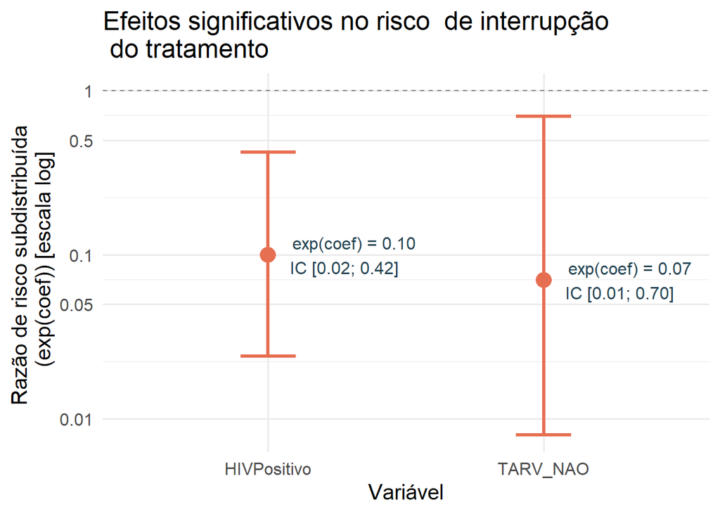

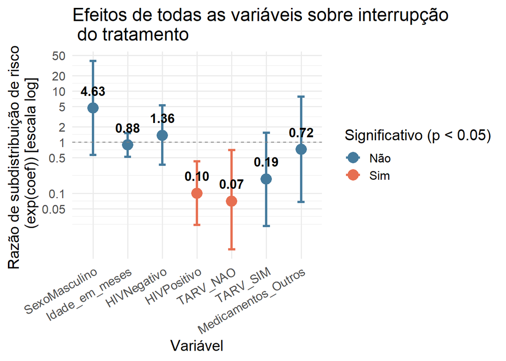

## Tratamento Completo:

```
## Modelo ajustado com sucesso para failcode 7
## Competing Risks Regression
##
## Call:
## crr(ftime = Dados_teste$Periodo_tratamento, fstatus = Dados_teste$Desfecho_num,
##     cov1 = matriz_filtrada, failcode = failcode_i)
##
##                             coef exp(coef) se(coef)      z p-value
## SexoMasculino              0.339      1.40    0.419  0.810   0.420
## Idade_em_meses            -0.151      0.86    0.332 -0.454   0.650
## HIVNegativo                0.274      1.32    0.800  0.343   0.730
## HIVPositivo                2.063      7.87    0.804  2.567   0.010
## TARVYesNoDontKnowType.NO   2.189      8.92    0.953  2.297   0.022
## TARVYesNoDontKnowType.YES  0.819      2.27    0.823  0.995   0.320
## MedicamentosOutros         1.283      3.61    0.613  2.092   0.036
##
##                           exp(coef) exp(-coef)  2.5% 97.5%
## SexoMasculino                  1.40      0.712 0.618  3.19
## Idade_em_meses                 0.86      1.163 0.449  1.65
## HIVNegativo                    1.32      0.760 0.274  6.31
## HIVPositivo                    7.87      0.127 1.628 37.99
## TARVYesNoDontKnowType.NO       8.92      0.112 1.378 57.76
## TARVYesNoDontKnowType.YES      2.27      0.441 0.452 11.39
## MedicamentosOutros             3.61      0.277 1.084 12.00
##
## Num. cases = 42
## Pseudo Log-likelihood = -88.8
## Pseudo likelihood ratio test = 18  on 7 df,
```

Resultados do modelo de Fine & Gray para tratamento completo

| Variável | Coef | exp(coef) | Erro Padrão | z | p-valor | 2.5% | 97.5% |
| --- | --- | --- | --- | --- | --- | --- | --- |
| SexoMasculino | 0.34 | 1.40 | 0.42 | 0.81 | 0.42 | 0.62 | 3.19 |
| Idade_em_meses | -0.15 | 0.86 | 0.33 | -0.45 | 0.65 | 0.45 | 1.65 |
| HIVNegativo | 0.27 | 1.32 | 0.80 | 0.34 | 0.73 | 0.27 | 6.31 |
| HIVPositivo | 2.06 | 7.87 | 0.80 | 2.57 | 0.01 | 1.63 | 37.99 |
| TARV_NAO | 2.19 | 8.92 | 0.95 | 2.30 | 0.02 | 1.38 | 57.76 |
| TARV_SIM | 0.82 | 2.27 | 0.82 | 1.00 | 0.32 | 0.45 | 11.39 |
| Medicamentos_Outros | 1.28 | 3.61 | 0.61 | 2.09 | 0.04 | 1.08 | 12.00 |

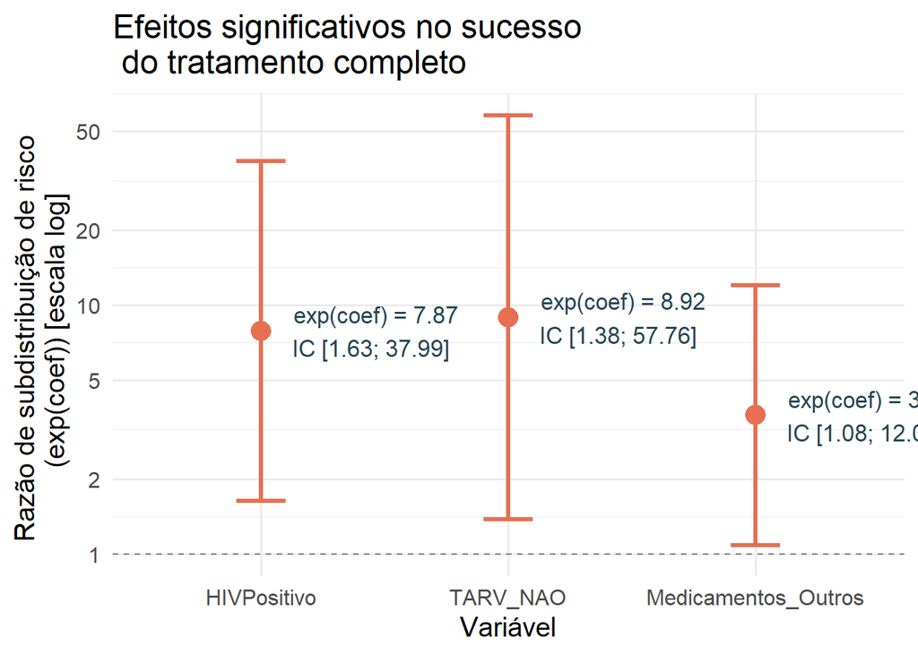

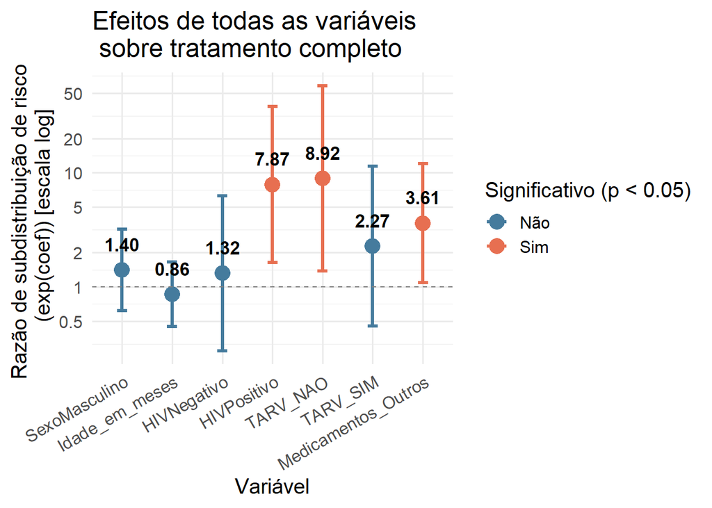

### Interpretação dos resultados do modelo Fine & Gray para tratamento completo

O modelo de riscos competitivos de Fine & Gray foi ajustado para analisar fatores associados ao **tratamento completo**.

Foram incluídas as variáveis:  
Sexo, Idade em meses, HIV (Negativo e Positivo), uso de TARV,  
e tipo de Medicamento (Isoniazida vs. Outros).

Veja o que cada resultado significa:

- **SexoMasculino:**  
  `exp(coef)` = 1.40  
  Homens tiveram 1,4 vezes mais chance de completar o tratamento do que mulheres  
  (ou grupo de referência), **mas esse resultado não é estatisticamente significativo** (p = 0.42).  
  *Na prática: essa diferença pode ter ocorrido apenas por acaso.*
- **Idade_em_meses:**  
  `exp(coef)` = 0.86  
  Para cada mês a mais de idade, há uma redução de 14% na chance de completar o tratamento  
  ([1 - 0.86] × 100% = 14%), mas **não foi significativo** (p = 0.65).
- **HIVNegativo:**  
  `exp(coef)` = 1.32  
  Pessoas HIV negativo tiveram 32% mais chance de completar, comparado ao grupo de referência,  
  mas **não foi significativo** (p = 0.73).
- **HIVPositivo:**  
  `exp(coef)` = 7.87  
  Pessoas HIV positivo tiveram quase 8 vezes mais chance de completar o tratamento  
  do que o grupo de referência, **resultado estatisticamente significativo** (p = 0.01).  
  *Intervalo de confiança*: de 1.63 a 37.99, ou seja, o aumento real pode estar entre 63% e 3699%.
- **TARV_NAO:**  
  `exp(coef)` = 8.92  
  Pessoas que **não** fazem TARV tiveram quase 9 vezes mais chance de completar o tratamento,  
  **resultado significativo** (p = 0.022).  
  *Intervalo de confiança*: de 1.38 a 57.76 (aumento real entre 38% e 5676%).
- **TARV_SIM:**  
  `exp(coef)` = 2.27  
  Fazer TARV foi associado a uma chance 2,3 vezes maior de completar o tratamento,  
  porém **não foi estatisticamente significativo** (p = 0.32).
- **Medicamentos_Outros:**  
  `exp(coef)` = 3.61  
  Quem usou “outros” medicamentos (Rifampicina/3HP) teve 3,6 vezes mais chance de completar  
  o tratamento em relação à Isoniazida, **resultado significativo** (p = 0.036).  
  *Intervalo de confiança*: de 1.08 a 12.00, ou seja, o aumento real pode estar entre 8% e 1100%.

#### Como transformar `exp(coef)` em porcentagem

- Para **valores acima de 1**:  
  Porcentagem de aumento = (`exp(coef)` - 1) × 100%  
  Exemplo: 3.61 → (3.61 - 1) × 100% = 261% mais chance
- Para **valores abaixo de 1**:  
  Porcentagem de redução = (1 - `exp(coef)`) × 100%  
  Exemplo: 0.86 → (1 - 0.86) × 100% = 14% menos chance

#### Observação sobre intervalo de confiança

- O intervalo de confiança mostra a faixa provável do efeito real.  
  Por exemplo, para Medicamentos_Outros (1.08 a 12.00):  
  o aumento na chance de completar o tratamento pode variar entre **8% e 12 vezes mais**.

### Conclusão geral das análises

Foram realizados dois modelos estatísticos de riscos competitivos para investigar os fatores associados à  
**interrupção do tratamento** e ao **tratamento completo**.

**Principais resultados:**

- Para **interrupção do tratamento**:
  - Pacientes HIV positivos apresentaram **90% menos risco** de interromper o tratamento  
    (`exp(coef)` = 0.10, IC 95%: 0.02 a 0.42, p = 0.0017).
  - Aqueles que **não faziam uso de TARV** apresentaram **93% menos risco** de interromper o tratamento  
    (`exp(coef)` = 0.07, IC 95%: 0.008 a 0.70, p = 0.023).
  - Essas associações foram estatisticamente significativas.
- Para **tratamento completo**:
  - Pacientes HIV positivos apresentaram quase **8 vezes mais chance** de completar o tratamento  
    (`exp(coef)` = 7.87, IC 95%: 1.63 a 37.99, p = 0.01).
  - Aqueles que **não faziam TARV** apresentaram quase **9 vezes mais chance** de completar o tratamento  
    (`exp(coef)` = 8.92, IC 95%: 1.38 a 57.76, p = 0.022).
  - O uso de esquemas alternativos de medicamentos (Rifampicina/3HP) foi associado a um aumento de  
    **3,6 vezes na chance de conclusão** do tratamento quando comparado ao uso exclusivo de Isoniazida  
    (`exp(coef)` = 3.61, IC 95%: 1.08 a 12.00, p = 0.036).
- **Esses achados sugerem que:**
  - O diagnóstico de HIV positivo e a ausência de TARV estão relacionados a maior adesão e conclusão do tratamento,  
    o que pode refletir um acompanhamento mais intenso desses pacientes ou outras características não capturadas nesta análise.
  - O uso de medicamentos alternativos à Isoniazida pode contribuir para melhores taxas de conclusão do tratamento.
  - Outras variáveis avaliadas (sexo, idade, HIV negativo, TARV sim) **não mostraram associação estatisticamente significativa**  
    em nenhum dos desfechos.

Esses resultados indicam a necessidade de atenção especial à escolha do esquema terapêutico  
e ao perfil clínico do paciente para aumentar as chances de sucesso do tratamento.  
Investigações adicionais podem ser úteis para compreender os mecanismos por trás dessas associações,  
especialmente em relação à TARV.

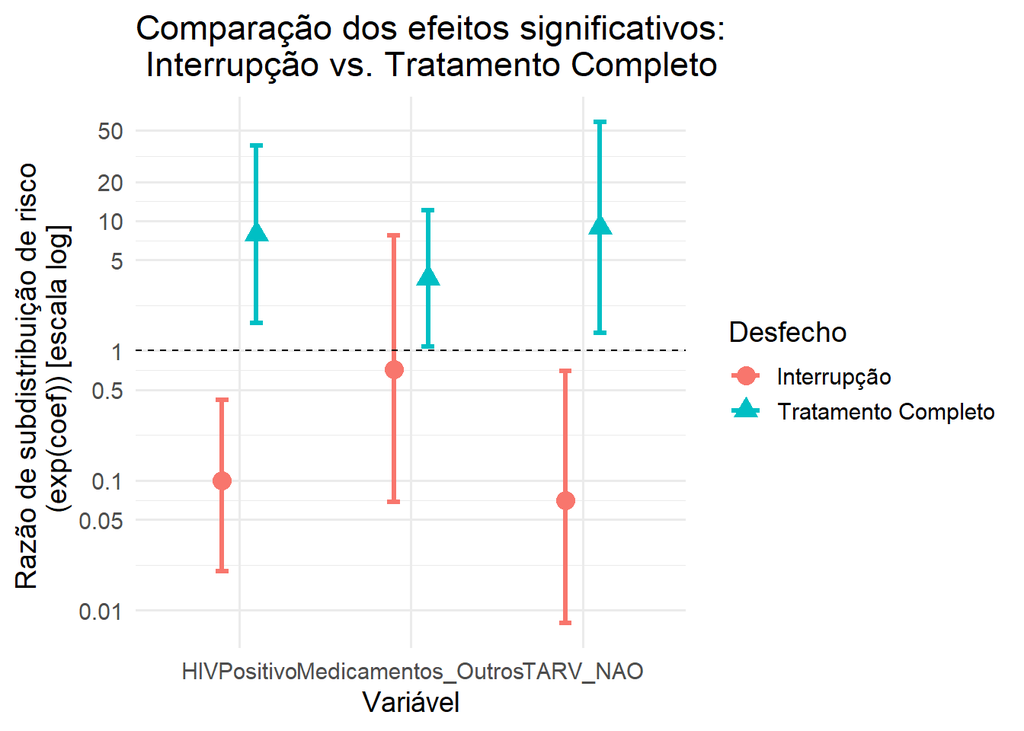